# BA-64060_Assignment 4

Inn Kyung Seo

2025-10-24

```r
pharma <- read.csv("C:/Users/beyou/Desktop/Pharmaceuticals.csv")
head(pharma)
```

```
##   Symbol                Name Market_Cap Beta PE_Ratio  ROE  ROA Asset_Turnover
## 1    ABT Abbott Laboratories      68.44 0.32     24.7 26.4 11.8            0.7
## 2    AGN      Allergan, Inc.       7.58 0.41     82.5 12.9  5.5            0.9
## 3    AHM        Amersham plc       6.30 0.46     20.7 14.9  7.8            0.9
## 4    AZN     AstraZeneca PLC      67.63 0.52     21.5 27.4 15.4            0.9
## 5    AVE             Aventis      47.16 0.32     20.1 21.8  7.5            0.6
## 6    BAY            Bayer AG      16.90 1.11     27.9  3.9  1.4            0.6
##   Leverage Rev_Growth Net_Profit_Margin Median_Recommendation Location Exchange
## 1     0.42       7.54              16.1          Moderate Buy       US     NYSE
## 2     0.60       9.16               5.5          Moderate Buy   CANADA     NYSE
## 3     0.27       7.05              11.2            Strong Buy       UK     NYSE
## 4     0.00      15.00              18.0         Moderate Sell       UK     NYSE
## 5     0.34      26.81              12.9          Moderate Buy   FRANCE     NYSE
## 6     0.00      -3.17               2.6                  Hold  GERMANY     NYSE
```

```r
pharma_num <- pharma[, c("Market_Cap", "Beta", "PE_Ratio", "ROE", "ROA",
                         "Asset_Turnover", "Leverage", "Rev_Growth", "Net_Profit_Margin")]
pharma_num <- data.frame(lapply(pharma_num, as.numeric))
```

```r
pharma_scaled <- scale(pharma_num)
head(pharma_scaled)
```

```
##      Market_Cap        Beta    PE_Ratio         ROE        ROA Asset_Turnover
## [1,]  0.1840960 -0.80125356 -0.04671323  0.04009035  0.2416121      0.0000000
## [2,] -0.8544181 -0.45070513  3.49706911 -0.85483986 -0.9422871      0.9225312
## [3,] -0.8762600 -0.25595600 -0.29195768 -0.72225761 -0.5100700      0.9225312
## [4,]  0.1702742 -0.02225704 -0.24290879  0.10638147  0.9181259      0.9225312
## [5,] -0.1790256 -0.80125356 -0.32874435 -0.26484883 -0.5664461     -0.4612656
## [6,] -0.6953818  2.27578267  0.14948233 -1.45146000 -1.7127612     -0.4612656
##        Leverage Rev_Growth Net_Profit_Margin
## [1,] -0.2120979 -0.5277675        0.06168225
## [2,]  0.0182843 -0.3811391       -1.55366706
## [3,] -0.4040831 -0.5721181       -0.68503583
## [4,] -0.7496565  0.1474473        0.35122600
## [5,] -0.3144900  1.2163867       -0.42597037
## [6,] -0.7496565 -1.4971443       -1.99560225
```

```r
library(factoextra)
```

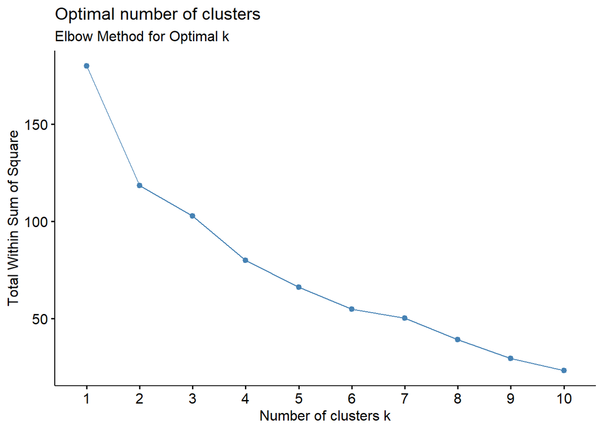

```r
fviz_nbclust(pharma_scaled, kmeans, method = "wss") +
  labs(subtitle = "Elbow Method for Optimal k")
```

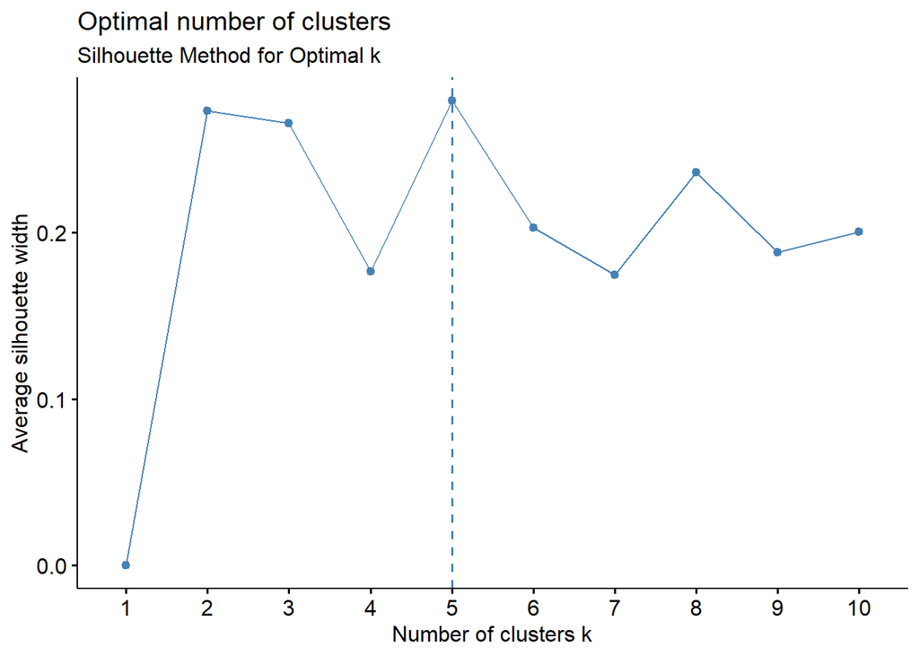

```r
fviz_nbclust(pharma_scaled, kmeans, method = "silhouette") +
  labs(subtitle = "Silhouette Method for Optimal k")
```

```r
set.seed(123)
km <- kmeans(pharma_scaled, centers = 3, nstart = 25)
```

```r
km
```

```
## K-means clustering with 3 clusters of sizes 4, 11, 6
##
## Cluster means:
##   Market_Cap       Beta   PE_Ratio        ROE        ROA Asset_Turnover
## 1 -0.6125361  0.2698666  1.3143935 -0.9609057 -1.0174553      0.2306328
## 2  0.6733825 -0.3586419 -0.2763512  0.6565978  0.8344159      0.4612656
## 3 -0.8261772  0.4775991 -0.3696184 -0.5631589 -0.8514589     -0.9994088
##     Leverage Rev_Growth Net_Profit_Margin
## 1 -0.3592866 -0.5757385        -1.3784169
## 2 -0.3331068 -0.2902163         0.6823310
## 3  0.8502201  0.9158889        -0.3319956
##
## Clustering vector:
##  [1] 2 1 1 2 3 1 2 3 3 2 2 3 2 3 2 2 2 1 2 3 2
##
## Within cluster sum of squares by cluster:
## [1] 20.54199 43.30886 32.14336
##  (between_SS / total_SS =  46.7 %)
##
## Available components:
##
## [1] "cluster"      "centers"      "totss"        "withinss"     "tot.withinss"
## [6] "betweenss"    "size"         "iter"         "ifault"
```

```r
km$centers
```

```
##   Market_Cap       Beta   PE_Ratio        ROE        ROA Asset_Turnover
## 1 -0.6125361  0.2698666  1.3143935 -0.9609057 -1.0174553      0.2306328
## 2  0.6733825 -0.3586419 -0.2763512  0.6565978  0.8344159      0.4612656
## 3 -0.8261772  0.4775991 -0.3696184 -0.5631589 -0.8514589     -0.9994088
##     Leverage Rev_Growth Net_Profit_Margin
## 1 -0.3592866 -0.5757385        -1.3784169
## 2 -0.3331068 -0.2902163         0.6823310
## 3  0.8502201  0.9158889        -0.3319956
```

```r
table(km$cluster)
```

```
##
##  1  2  3
##  4 11  6
```

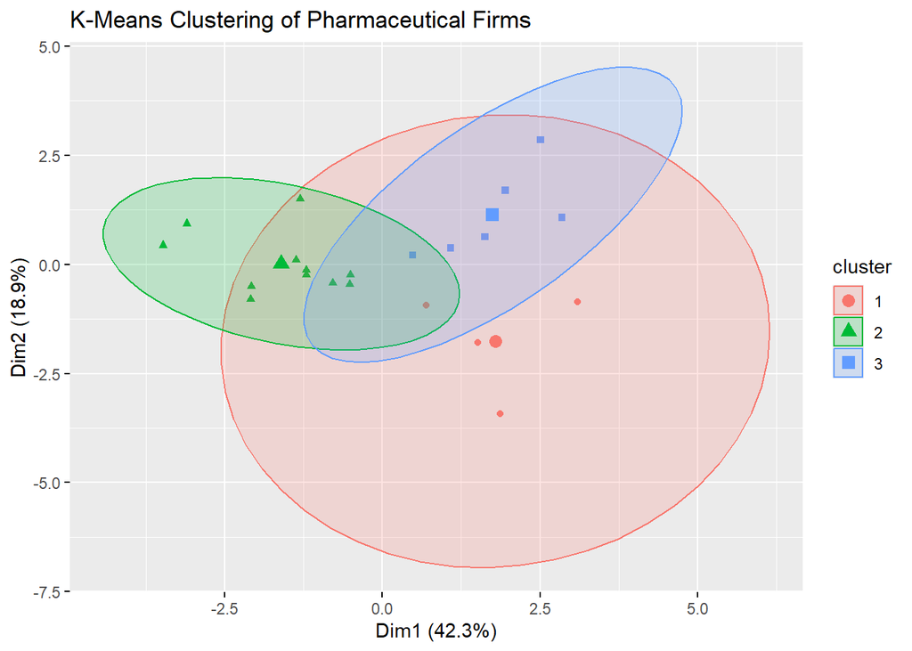

```r
fviz_cluster(km, data = pharma_scaled, geom = "point", ellipse.type = "norm") +
  labs(title = "K-Means Clustering of Pharmaceutical Firms")
```

```r
aggregate(pharma_num, by = list(Cluster = km$cluster), mean)
```

```
##   Cluster Market_Cap      Beta PE_Ratio  ROE       ROA Asset_Turnover  Leverage
## 1       1   21.75500 0.5950000 46.90000 11.3  5.100000      0.7500000 0.3050000
## 2       2   97.11364 0.4336364 20.95455 35.7 14.954545      0.8000000 0.3254545
## 3       3    9.23500 0.6483333 19.43333 17.3  5.983333      0.4833333 1.2500000
##   Rev_Growth Net_Profit_Margin
## 1    7.01000           6.65000
## 2   10.16455          20.17273
## 3   23.49000          13.51667
```

**Interpret**

**(a) Determine the optimal number of clusters using Elbow and Silhouette methods**

**(b) Cluster Analysis and Interpretation**

Three clusters were identified, consisting of 4, 11, and 6 firms respectively.  
Each group shows distinct financial characteristics.

**Cluster 1 (n = 4)**  
These firms have high price-to-earnings ratios but relatively low returns on equity and returns on assets.They also tend to have small to medium market capitalizations.  
This suggests they are valued highly despite limited profitability, likely because investors expect strong future growth or innovation potential.

**Cluster 2 (n = 11)**  
Firms in this cluster have the largest market capitalizations and the highest profitability measures such as ROE, ROA, and net profit margin. They maintain strong operational efficiency and stable balance sheets.This cluster represents financially strong, stable, and efficient market leaders that dominate the pharmaceutical industry.

**Cluster 3 (n = 6)**  
These firms are smaller and less mature, with moderate ROE and lower asset turnover and margins.They are likely in early or transitional stages of growth, focusing on improving efficiency and profitability over time.This cluster represents developing and transitional firms within the industry.

**(d) Cluster Naming**

By applying k-Means clustering (k = 3) to nine standardized financial variables, this analysis successfully grouped 21 pharmaceutical firms into three distinct categories. The results reveal important structural differences within the industry.

**Cluster 1 – Emerging Innovation Firms:** These are smaller companies with high market valuations but modest current profitability, reflecting investor optimism toward innovation, research, and long-term growth potential.

**Cluster 2 – Industry Leaders:** This cluster represents financially strong, stable, and operationally efficient firms that consistently achieve high profitability and maintain dominant positions in the global pharmaceutical market.

**Cluster 3 – Growth Stage Firms:** These emerging firms are in the process of improving operational efficiency and strengthening financial stability as they transition toward greater maturity and sustainable growth. This clustering analysis provides valuable insights into the financial structure of the pharmaceutical industry.It helps analysts and investors better understand competitive positioning, identify performance patterns,and recognize which firms align with different strategic or investment objectives.

**Conclusion**

The k-Means clustering analysis, based on nine standardized financial variables, segmented 21 pharmaceutical firms into three meaningful groups. These clusters reveal structural diversity across the industry, highlighting differences in firm size, profitability, and strategic positioning. Emerging Innovation Firms: Smaller companies with limited current profitability but strong investor confidence, reflecting high expectations for innovation and future expansion. Industry Leaders: Large, financially robust firms that consistently demonstrate high efficiency, strong returns, and long-term market dominance. Growth Stage Firms: Emerging players steadily enhancing operational capabilities and financial performance as they progress toward maturity. In conclusion, this analysis provides a comprehensive view of the pharmaceutical industry’s financial landscape.It enables analysts and investors to identify peer groups, assess competitive advantages, and make informed strategic or investment decisions based on each firm’s growth trajectory and performance characteristics.